# GO Enrichment Analysis

Steve Pederson

01 June, 2017

# Setup

```r
library(readr)
library(readxl)
library(dplyr)
library(tibble)
library(magrittr)
library(parallel)
library(ggplot2)
library(reshape2)
library(GO.db)
library(GOstats)
library(xtable)
library(pander)
library(RColorBrewer)
library(Rgraphviz)
library(stringr)
library(biomaRt)
library(scales)
library(GenomicRanges)
library(GenomicFeatures)
library(ggbio)
logit <- binomial()$linkfun
inv.logit <- binomial()$linkinv
```

## Data cleaning

Load in the entire Excel file

```r
snpFile <- file.path("..", "results", "genes_scores_snps.40k.xls")
snpScores <- read_excel(path = snpFile, sheet = 1,
                        col_types = c("text", "numeric", "skip")[c(rep(1, 3), 3, 1,
                                                                    rep(2, 8), 1, 2,
                                                                    rep(1, 5), 2, 3, 2, 2)])
```

The data as loaded has 3678 SNP-to-gene mappings with missing data, and complete data for 14962 mappings. It was assumed that missing data was intentional, and these SNP-to-gene mappings were removed from the dataset.

The following steps were taken as data filtering:

1. Removal of the 3678 genes with missing data
2. Removal of the fourth column. This was simply a numeric id for each chromosome which was surplus to requirements.
3. Chromosomes 1 - 21 were loaded by default as character strings with six decimal places and these were corrected. An alternative specification for Chromosomes was also created using the `chr` prefix to more clearly delineate between text and numeric values.
4. Missing gene names were specified by **Excel** as having the name `0.00`, and these were re-assigned as blank

```r
snpScores %<>%
  filter(!is.na(p.fdr)) %>%
  dplyr::select(ensembl_gene_id,
                contains("chr"),
                starts_with("gene"),
                min_snp,
                p = score,
                starts_with("p"),
                contains("aff"),
                ends_with("stream")
                ) %>%
  rowwise() %>%
  mutate(gene_name = gsub("0.00", "", gene_name),
         chr_name = ifelse(grepl("^(GL|AA)", chr_name),
                           chr_name,
                           paste0("chr", as.integer(chr_name))),
         in_gene = all(pos >= gene_start, pos <= gene_end),
         upstream = as.logical(upstream),
         downstream = as.logical(downstream)) %>%
  ungroup()
```

After cleaning, this original dataset contained 15 unique SNPs which are significant to an `FDR` $\approx$ 0.1. These are associated with 32 unique Ensembl gene IDs.

## Filtering based on Identified Samples

```r
geno2Num <- function(geno){
  str_split_fixed(geno, pattern = "/", n = 3) %>%
        as.integer() %>%
        matrix(ncol = 3) %>%
        rowSums()
}
```

```r
totals <- data_frame(aff = max(geno2Num(snpScores$aff)),
                                         unaff = max(geno2Num(snpScores$unaff)))
genoThresh <- 0
keep <- totals*genoThresh
```

For the results as supplied, the genotypes for those marked as `aff` were assumed to be the rabbits who died, whilst the `unaff` remainder were assumed to be the survivors. The sample sizes were *42* and *36* for *aff* and *unaff* respectively.

```r
snpScores %<>%
  mutate(nAff = geno2Num(aff),
         nUnaff = geno2Num(unaff))
```

A new set of FDR-adjusted $p$-values was created based on the filtered data. In addition, these adjusted values were calculated *per SNP*, instead of *per gene*.

```r
newPadj <- snpScores %>%
  filter(nAff >= keep$aff,
         nUnaff >= keep$unaff) %>%
  dplyr::select(min_snp, p) %>%
  distinct(min_snp, .keep_all = TRUE) %>%
  mutate(FDR = p.adjust(p, "fdr"))
```

These were added to the data to account for the removal of SNPs with low rates of genotype identification.

```r
snpScores %<>%
  filter(nAff >= keep$aff,
         nUnaff >= keep$unaff) %>%
  left_join(newPadj) %>%
  dplyr::select(-p.fdr)
```

This gave a total of 9229 unique SNPs, with 14962 genes associated (i.e. within 40kb).

## Assessment of Linkage

In order to account for linkage the distances between neighbouring candidate markers was characterised. Where only a single SNP was identified on a scaffold (or chromosome) this distance was defined as infinite.

```r
distances <- snpScores %>%
  arrange(chr_name, pos) %>%
  distinct(min_snp, .keep_all = TRUE) %>%
  split(f = .$chr_name) %>%
  lapply(function(x){
    if (nrow(x) == 1){
      d <- Inf
    }
    else {
      d <- x$pos[-1] - x$pos[-nrow(x)]
    }
    d
  }) %>%
  unlist
```

```r
checkDistances <- c(10, 20, 40, 100)*1000
```

The median distance between neighbouring SNPs was found to be 141,607bp. Using the distances of *10*, *20*, *40* and *100* kb respectively, a total of *1.0%*, *3.2%*, *9.9%* and *36.7%* SNPs were found to have neighbours within these distances.

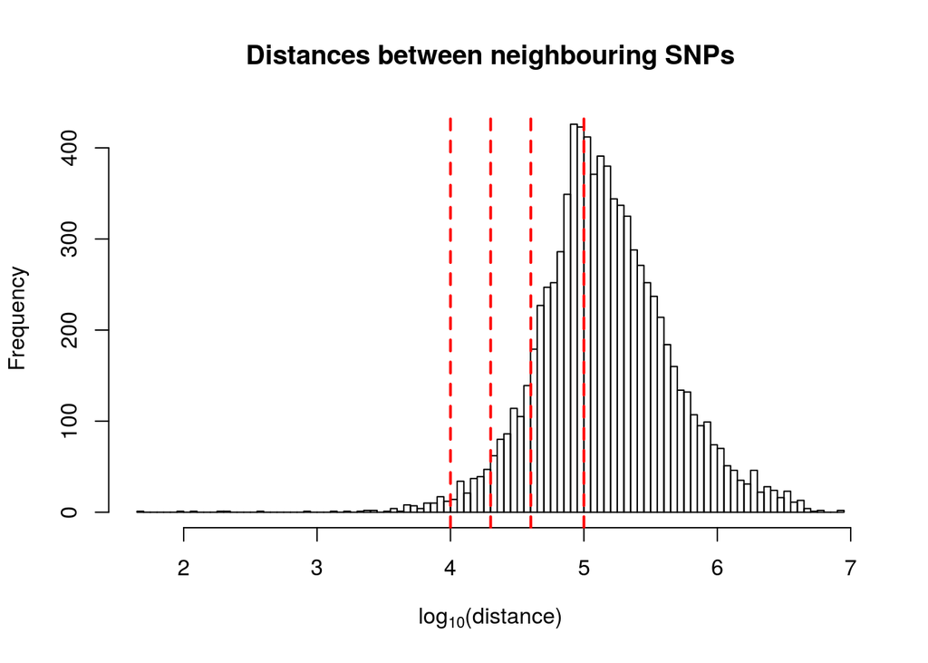

Histogram of the distances between neighbouring SNPs. The distances of *10*, *20*, *40* and *100* kb are shown as the red vertical line. Distances are measured in nucleotides

## Significant SNPs

```r
pCut <- 0.001
fdrCut <- snpScores %>%
  filter(p < pCut) %>%
  summarise(FDR = max(FDR)) %>%
  extract2("FDR")
```

Selecting the SNPs with a $p$-values $<$ 0.001 gave an FDR of 12.8%, and a total of 72 significant SNPs. These were associated with 133 distinct genes

# Manhattan Plot

A Manhattan plot was generated to summarise the results. This was done by forming a `GRanges` object, the plotting using the package `ggbio`. Of the 72 significant SNPs defined above, a total of 41 were located on the autosomes (i.e. chr1 to chr21, disregarding the scaffolds). In total 6725 autosomal SNPs were in the set tested above.

```r
gr <- snpScores %>%
  filter(chr_name %in% paste0("chr", 1:21)) %>%
  distinct(min_snp, .keep_all = TRUE) %>%
  arrange(chr_name, pos) %>%
  DataFrame() %>%
  makeGRangesFromDataFrame(keep.extra.columns=TRUE,
                           seqnames.field = "chr_name",
                           start.field = "pos",
                           end.field = "pos")
```

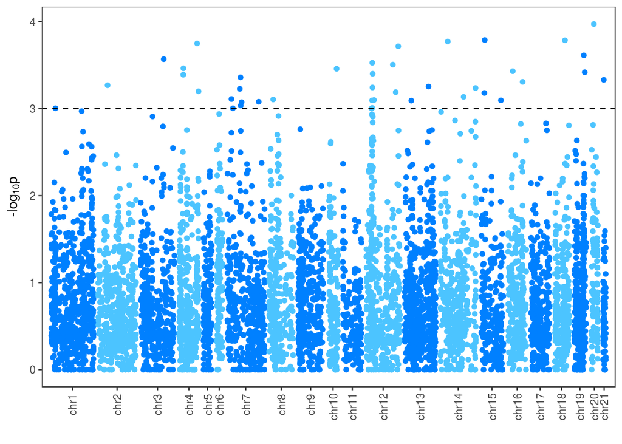

# Significant SNPs in Exons

Firstly, a list of exons needs to be generated from a the `gff3` file.

```r
gtfFile <- file.path("..", "meta", "Oryctolagus_cuniculus.OryCun2.0.87.gff3")
exonGR <- makeTxDbFromGFF(gtfFile) %>% exonsBy(by = "gene")
```

The unique SNPs mapping to exons were then found.

```r
snpInExon <- snpScores %>%
  filter(p < pCut) %>%
  mutate(chr_name = gsub("chr", "", chr_name)) %>%
  arrange(chr_name, gene_start) %>%
  dplyr::select(chr_name, pos, ensembl_gene_id, min_snp, p) %>%
  distinct(min_snp,.keep_all = TRUE) %>%
  as.data.frame() %>%
  makeGRangesFromDataFrame(keep.extra.columns = TRUE,
                           ignore.strand =TRUE,
                           seqinfo = seqinfo(exonGR),
                           seqnames.field = "chr_name",
                           start.field = "pos",
                           end.field = "pos") %>%
  extract(queryHits(findOverlaps(., exonGR))) %>%
  subset(!duplicated(min_snp))
```

This gave a total of 5 significant SNPs which were within exons. These were then mapped to the appropriate genes to find where they mapped.

```r
exonWithSnp <- exonGR %>%
  unlist() %>%
  extract(subjectHits(findOverlaps(snpInExon, .)))
```

This gave a total of 6 genes with SNPs within an exon, and clearly one SNP was within exons from two genes on opposite strands.

```r
snp2Gene <- snpInExon %>%
  as.data.frame() %>%
  dplyr::select(seqnames, pos = start, ensembl_gene_id, min_snp) %>%
  right_join(exonWithSnp %>%
               as.data.frame %>%
               rownames_to_column("Gene")) %>%
  dplyr::select(min_snp,
                chr = seqnames,
                pos,
                ensembl_gene_id,
                Gene,
                strand,
                exon_start = start,
                exon_end = end)
```

Significant SNPs within exons

| min_snp | chr | pos | ensembl_gene_id | Gene | strand | exon_start | exon_end |
| --- | --- | --- | --- | --- | --- | --- | --- |
| 16674_72 | 12 | 29,170,751 | ENSOCUG00000006638 | KIF6 | - | 29,170,665 | 29,170,754 |
| 22775_31 | 13 | 109,976,895 | ENSOCUG00000017190 | C8A | - | 109,976,807 | 109,977,029 |
| 75479_35 | 18 | 50,410,769 | ENSOCUG00000005714 | NFKB2 | + | 50,410,679 | 50,410,892 |
| 75479_35 | 18 | 50,410,769 | ENSOCUG00000005714 | PSD | - | 50,408,800 | 50,413,003 |
| 148736_46 | 4 | 90,190,951 | ENSOCUG00000000187 | CKAP4 | + | 90,190,259 | 90,191,587 |
| 161821_70 | 7 | 146,540,948 | ENSOCUG00000007978 | NRP2 | + | 146,540,857 | 146,541,119 |

These were additionally written to the file `sigSnpsInExons.csv`

```r
snp2Gene %>% write_csv("../results/sigSnpsInExons.csv")
```

# GO Analysis

## Mapping Genes To GO Terms

Genes were mapped to GO terms using the mappings contained in `biomaRt` as of `20161210`.

```r
mart <- useMart("ENSEMBL_MART_ENSEMBL",
                dataset = "ocuniculus_gene_ensembl",
                host = "oct2016.archive.ensembl.org")
attr <-  data_frame(name = c("ensembl_gene_id", "external_gene_name", "description",
                             "namespace_1003", "go_id",
                             "name_1006", "definition_1006", "go_linkage_type")) %>%
  left_join(listAttributes(mart)) %>%
  filter(page == "feature_page") %>%
  dplyr::select(name, description)
allGO <- getBM(attributes = attr$name,
               filters = "ensembl_gene_id",
               values = snpScores$ensembl_gene_id,
               mart = mart) %>%
  set_names(attr$description) %>%
  as_data_frame()
write_delim(allGO, "../results/allGO.txt")
```

```r
allGO <- read_delim("../results/allGO.txt", delim = " ")
```

At this stage the gene names were added to the SNPs and the objects was exported as a `csv` file.

```r
snpScores %<>% left_join(dplyr::select(allGO, -contains("GO")) %>%
                           distinct(`Ensembl Gene ID`, .keep_all = TRUE),
                         by = c("ensembl_gene_id" = "Ensembl Gene ID")) %>%
  mutate(gene_name = `Associated Gene Name`) %>%
  dplyr::select(-contains("Associated")) %>%
  rowwise() %>%
  mutate(dist2Gene = if_else(in_gene, 0,
                             min(abs(pos - gene_start), abs(pos - gene_end)))) %>%
  dplyr::select(ensembl_gene_id, ends_with("name"), Description, everything())
```

```r
write_csv(snpScores, "../results/filteredSNPScores.csv")
```

In addition to this, the significant SNPs/genes from the potentially interesting region of Chromosome 12 were exported as a separate file.

```r
snpScores %>%
  filter(p < pCut,
         chr_name == "chr12") %>%
  arrange(pos) %>%
  readr::write_csv("../results/chr12.csv")
```

## Mapping Genes to GO terms

In keeping with prior analysis, the GO terms will be associated with each SNP, as opposed to each gene. As each SNP may be assigned to multiple genes, and these may share common GO terms this will ensure that GO terms are only counted once per SNP.

```r
geneSplit <- snpScores %>%
  split.data.frame(f = .$ensembl_gene_id)
```

The data was then split by gene to collect the set of GO terms for each gene.

```r
gene2GO <- names(geneSplit) %>%
  mclapply(function(x){
    allGO %>%
    filter(`Ensembl Gene ID` %in% x) %>%
      distinct(`GO Term Accession`, .keep_all = TRUE)
  },
  mc.cores = 20) %>%
  set_names(names(geneSplit))
```

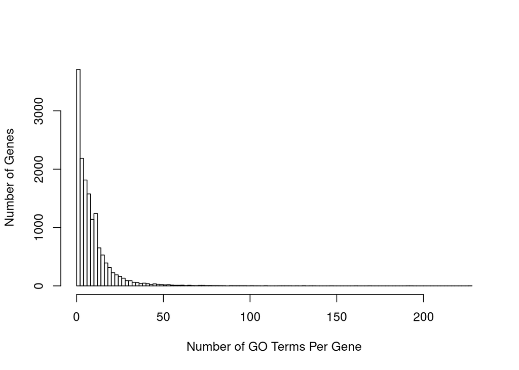

Distribution of GO Terms annotated to each gene.

```r
gene2GO %>%
  vapply(nrow, integer(1)) %>%
  hist(breaks = 100,
       main = "",
       xlab = "Number of GO Terms Per Gene",
       ylab = "Number of Genes")
```

## Building Full GO Graphs

The inheritable nature of GO terms means that every GO term ascribed to a SNP will also inherit the full set of ancestor terms back to the root of the ontology. The complete set of GO annotations for each SNP were then built for each SNP.

```r
allAncestorBP <- GOBPANCESTOR %>%
  as.list() %>%
  extract(!is.na(.))
allAncestorCC <- GOCCANCESTOR %>%
  as.list() %>%
  extract(!is.na(.))
allAncestorMF <- GOMFANCESTOR %>%
  as.list() %>%
  extract(!is.na(.))
```

```r
fullGene2GO <-
  mclapply(gene2GO,
           function(x){
             terms <- split(x, x$`GO domain`) %>%
               lapply(extract2, "GO Term Accession")
             list(
               BP = allAncestorBP[terms$biological_process] %>%
                 unlist %>%
                 c(terms$biological_process) %>%
                 unique(),
               CC = allAncestorCC[terms$cellular_component] %>%
                 unlist %>%
                 c(terms$cellular_component) %>%
                 unique(),
               MF = allAncestorMF[terms$molecular_function] %>%
                 unlist %>%
                 c(terms$molecular_function) %>%
                 unique()
             )
           },
           mc.cores = 20) %>%
  set_names(names(gene2GO))
```

These complete annotations were then broken into separate ontologies in separate `R` objects.

```r
fullGene <- list(
  BP = lapply(fullGene2GO, extract2, "BP"),
  CC = lapply(fullGene2GO, extract2, "CC"),
  MF = lapply(fullGene2GO, extract2, "MF")
)
```

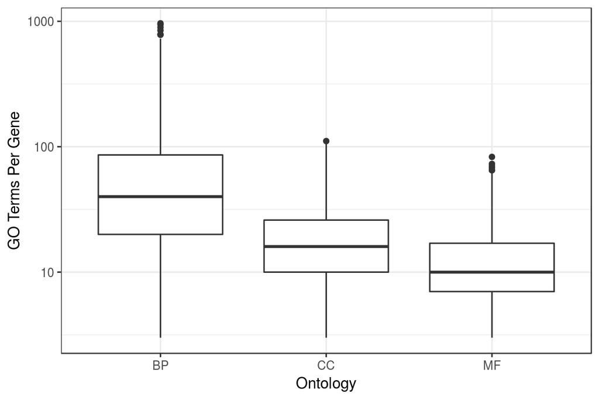

Complete annotations of GO terms to SNPs after incorporating all parent terms.

# Analysis

## SNP and GO Term preparation

The lists of parents and children for each GO term were formed, and terms directly under the ontology roots were collected as the `firstLevel terms. The terms directly under these were also collected as the`secondLevel` terms.

```r
allParents <- list(
  BP = GOBPPARENTS %>%
    as.list() %>%
    extract(!is.na(.)),
  CC = GOCCPARENTS %>%
    as.list() %>%
    extract(!is.na(.)),
  MF = GOMFPARENTS %>%
  as.list() %>%
  extract(!is.na(.))
)
```

```r
allChildren <- list(
  BP = GOBPCHILDREN %>%
    as.list() %>%
    extract(!is.na(.)),
  CC = GOCCCHILDREN %>%
    as.list() %>%
    extract(!is.na(.)),
  MF = GOMFCHILDREN %>%
  as.list() %>%
  extract(!is.na(.))
)
```

```r
rootNodes <- c("all", "GO:0008150", "GO:0003674", "GO:0005575") %>%
  set_names(c("all", "BP", "MF", "CC"))
firstLevel <- rootNodes %>%
  extract(-1) %>%
  names() %>%
  sapply(function(x){
    allChildren[[x]][[rootNodes[x]]]
  },
  simplify = FALSE)
secondLevel <- firstLevel %>%
  names %>%
  sapply(function(x){
    unlist(allChildren[[x]][firstLevel[[x]]])
  },
  simplify = FALSE)
```

```r
sigIDs <- snpScores %>%
  filter(p < pCut) %>%
  extract2("ensembl_gene_id") %>%
  unique
```

The set of GO terms within the 133 significant genes (FDR $<$ 12.8%) were then collected, and collated into their respective ontologies. Root terms, along with first and second-level GO terms were removed from each ontology.

```r
goInGenes <- list(
  BP = fullGene2GO %>%
    extract(sigIDs) %>%
    lapply(extract2, "BP") %>%
    unlist %>%
    unique %>%
    setdiff(rootNodes) %>%
    setdiff(firstLevel$BP) %>%
    setdiff(secondLevel$BP) %>%
    # setdiff(thirdLevel$BP) %>%
    intersect(unlist(allParents$BP)),
  CC = fullGene2GO %>%
    extract(sigIDs) %>%
    lapply(extract2, "CC") %>%
    unlist %>%
    unique %>%
    setdiff(rootNodes) %>%
    setdiff(firstLevel$CC) %>%
    setdiff(secondLevel$CC) %>%
    # setdiff(thirdLevel$CC) %>%
    intersect(unlist(allParents$CC)),
  MF = fullGene2GO %>%
    extract(sigIDs) %>%
    lapply(extract2, "MF") %>%
    unlist %>%
    unique %>%
    setdiff(rootNodes) %>%
    setdiff(firstLevel$MF) %>%
    setdiff(secondLevel$MF) %>%
    # setdiff(thirdLevel$MF) %>%
    intersect(unlist(allParents$MF))
)
```

```r
list(vapply(firstLevel, length, integer(1)),
     vapply(secondLevel, length, integer(1)),
     vapply(goInGenes, length, integer(1))) %>%
  as.data.frame() %>%
  set_names(c("First Level",
              "Second Level",
              "Tested Terms")) %>%
  rownames_to_column("Ontology") %>%
  mutate(`Second Level` = `Second Level` - `First Level`) %>%
  pander(caption = "Structure of GO Terms removed (1st and 2nd Level) and tested")
```

Structure of GO Terms removed (1st and 2nd Level) and tested

| Ontology | First Level | Second Level | Tested Terms |
| --- | --- | --- | --- |
| BP | 27 | 429 | 1919 |
| MF | 19 | 145 | 179 |
| CC | 22 | 349 | 265 |

## Parent-Child Analysis

```r
minSigG <- 2
```

```r
pcFun <- function(child, ontology, allGenes = fullGene, sigGenes = sigIDs,
                  parentList = allParents, minSig = minSigG ){

  # Check the ontology is correct for the term
  stopifnot(child %in% names(parentList[[ontology]]))
  parents <- parentList[[ontology]][[child]]

  # Get all SNPs in parents
  parentSnps <- vapply(allGenes[[ontology]],
                       function(x){any(parents %in% x)},
                       logical(1)) %>%
    which %>%
    names

  # Get all SNPs in the child
  childSnps <- vapply(allGenes[[ontology]],
                       function(x){any(child %in% x)},
                       logical(1)) %>%
    which %>%
    names

  # Form a data_frame & fit the GLM
  df <- data_frame(SNP = parentSnps,
                   Child = SNP %in% childSnps,
                   Sig = SNP %in% sigGenes)

  if (nrow(filter(df, Child, Sig)) >= minSig & mean(df$Child) < 1) {
    # Only fit the model if there are enough
    # sigGenes in the child set of snps.
    mod <- glm(Child~Sig, "binomial", df)

    #Format the results as a data_frame
    out <- data_frame(
      Term = child,
      Ontology = ontology,
      TotalParent = nrow(df),
      TotalChild = sum(df$Child),
      SigInParent = sum(df$Sig),
      SigInChild = nrow(filter(df, Sig, Child)),
      Expected = inv.logit(coef(mod)[1])*SigInParent,
      p = coef(summary(mod))["SigTRUE", "Pr(>|z|)"]

    )
  }
  else{
    out <- data_frame(
      Term = child,
      Ontology = ontology,
      TotalParent = nrow(df),
      TotalChild = sum(df$Child),
      SigInParent = sum(df$Sig),
      SigInChild = nrow(filter(df, Sig, Child)),
      Expected = TotalChild*SigInParent/TotalParent,
      p = NA
    )
  }

  out

}
```

```r
str2Width <- function(x, width = 30){
  long <- nchar(x) > width
  x[long] <- paste0(strtrim(x[long], width-3), "...")
  x
}
```

## Biological Process

```r
pcBP <- goInGenes$BP %>%
  mclapply(pcFun, ontology = "BP", minSig = minSigG, mc.cores = 20) %>%
  bind_rows() %>%
  filter(!is.na(p)) %>%
  mutate(FDR = p.adjust(p, "BH")) %>%
  arrange(p)
```

This list of GO Terms was exported as the file `parentChildBP.csv`

```r
pcBP %>%
  mutate(adjP = p.adjust(p, "holm")) %>%
  dplyr::select(-Ontology) %>%
  mutate(Description = Term(Term),
         Description = str2Width(Description, 33),
         Expected = format(Expected, digits = 1),
         p = format(p, digits = 3),
         adjP = format(adjP, digits = 2),
         FDR = format(FDR, digits = 2)) %>%
  dplyr::select(Term, Description,
                starts_with("Total"),
                starts_with("Sig"),
                Expected, p, adjP, FDR) %>%
  dplyr::rename(AllParent = TotalParent,
         AllChild = TotalChild,
         Exp = Expected) %>%
  write_csv("../results/parentChildBP.csv")
```

## Plots For Significant GO Terms

```r
resFDR <- 0.1
sigBPGO <- pcBP %>%
  mutate(FDR = p.adjust(p, "BH")) %>%
  filter(FDR < resFDR) %>%
  extract2("Term")
```

Using a FDR of 0.1, a total of 2 GO terms (i.e. _GO:0090398_ and _GO:0006896_) were found to be significantly enriched from the Biological Process Ontology.

In order to plot these as directed acyclic graph, several preparatory steps were required. First the colours were defined manually and a legend prepared. A minimum $p$-value of `1e-04` was assumed when creating the legend.

```r
nCols <- 101
pSeq <- seq(0,4, length.out = nCols)
plotCols <- colorRampPalette(c("#FFFFFF", brewer.pal(7, "YlOrRd")))(nCols + 9)[seq(nCols)]
```

```r
lg <- data_frame(x = seq(nCols) - 1) %>%
  ggplot(aes(x = x, y = 1, fill = as.factor(x))) +
  geom_raster() +
  scale_fill_manual(values = plotCols) +
  scale_x_continuous(breaks = quantile(seq(nCols)-1, probs = c(0, 0.5, 1)),
                     labels = quantile(pSeq, probs= c(0, 0.5, 1)),
                     expand = c(0, 0))+
  scale_y_continuous(expand = c(0, 0)) +
  theme_bw() +
  guides(fill = FALSE) +
  labs(y = c(), x = c(), title = expression(paste(-log[10], "(p)"))) +
  theme(axis.text.y = element_blank(),
        axis.ticks.y = element_blank(),
        plot.title = element_text(size = 10, hjust = 0.5))
```

### First Plot of BP GO terms

Next a `GraphNEL` object was prepared by merging individual graphs for each term, using the function `oneGOGraph`. The root GO term `all` was removed from these plots as it was redundant.

```r
allBPPlot <- oneGOGraph(sigBPGO[1], GOBPANCESTOR)
for (i in 2:length(sigBPGO)){
  allBPPlot %<>% join(oneGOGraph(sigBPGO[i], GOBPANCESTOR))
}
allBPPlot %<>% removeNode("all", .)
```

As this plot will contain edges connecting all nodes, edges not directly connecting parents and children need to be removed.

```r
nodeNames<- allBPPlot %>%
  nodeData() %>%
  names()
validEdges <- nodeNames %>%
  lapply(function(x){
    parents <- allParents$BP[[x]]
    paste(rep(x, length(parents)), parents, sep="|")
  }) %>%
  unlist()
rmEdges <- allBPPlot %>%
  edgeData() %>%
  names %>%
  setdiff(validEdges) %>%
  strsplit(split = "\\|") %>%
  as.data.frame() %>%
  t %>%
  set_rownames(c())
allBPPlot %<>% removeEdge(rmEdges[,1], rmEdges[,2], .)
```

Next the attributes for plotting each node need to be defined manually. This step unfortunately involved significant trial and error.

```r
termCols <- nodeNames %>%
  mclapply(pcFun, ontology = "BP", mc.cores = 20) %>%
  bind_rows() %>%
  mutate(p = -log10(p),
         p = replace(p, is.na(p), 0),
         colGrp = findInterval(p, pSeq)) %>%
  extract2("colGrp") %>%
  set_names(nodeNames)
termCols[!names(termCols) %in% pcBP$Term] <- NA
```

```r
nodeAttrs <- makeNodeAttrs(allBPPlot, shape = "ellipse", fillcolor=rgb(1, 1, 1))
nodeNames <- names(nodeAttrs$fillcolor)
nodeAttrs$fillcolor <- termCols[nodeNames] %>% set_names(nodeNames)
nodeAttrs$fillcolor[is.na(nodeAttrs$fillcolor)] <- 1
nodeAttrs$fillcolor <- plotCols[nodeAttrs$fillcolor] %>% set_names(nodeNames)
nodeAttrs$label <- paste(nodeNames,
                         str_wrap(Term(nodeNames), 18),
                         sep = "\n") %>%
  set_names(nodeNames)
nodeAttrs$shape[sigBPGO] <- "rectangle"
attrs <- list(node = list(fontsize = 16,
                          fixedSize =  FALSE),
              edge = list(color = "grey70"))
```

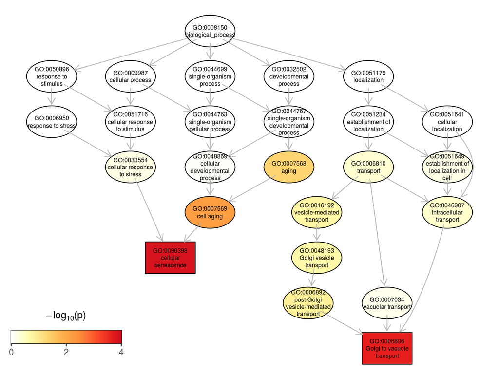

Significantly enriched GO terms are shown as rectangles, along with their relationship to parent terms in ellipses. Colours indicate -log$_{10}$ of the results from tests for enrichment. First and second level GO terms were not tested for enrichment.

```r
scaleEllipse <- 1.4
goPlot <- allBPPlot %>%
  reverseEdgeDirections() %>%
  layoutGraph(nodeAttrs = nodeAttrs, attrs = attrs, layoutType = "dot")
graphRI <- graphRenderInfo(goPlot)
graphRI$bbox <- matrix(c(-20, -40, 20, 20), byrow = TRUE, ncol=2) + graphRI$bbox
graphRenderInfo(goPlot) <- graphRI
nodeRI <- nodeRenderInfo(goPlot)
nodeRI$lWidth <- nodeRI$lWidth*scaleEllipse
nodeRI$rWidth <- nodeRI$rWidth*scaleEllipse
nodeRI$height <- nodeRI$height*scaleEllipse
nodeRenderInfo(goPlot) <- nodeRI
renderGraph(goPlot)
vp1 <- viewport(0.13, 0.15, 0.25, 0.14)
print(lg, vp = vp1)
```

### GO Terms to Genes

```r
pcBP %>%
  filter(Term %in% sigBPGO) %>%
  mutate(Description = Term(Term)) %>%
  dplyr::select(Term, Description) %>%
  split(f = .$Term) %>%
  lapply(function(df){
    out <- names(fullGene$BP) %>%
      extract(vapply(fullGene$BP, function(x){df$Term %in% x}, logical(1))) %>%
      intersect(sigIDs) %>%
      data_frame() %>%
      set_names("ensembl_gene_id") %>%
      left_join(dplyr::select(snpScores, ensembl_gene_id, gene_name)) %>%
      mutate(`Term` = df[["Term"]],
             Description = df[["Description"]])
  }) %>%
  bind_rows()  %>%
  readr::write_csv("../results/topBPGenes.csv")
```

## Cellular Component

```r
pcCC <- goInGenes$CC %>%
  mclapply(pcFun, ontology = "CC", minSig = minSigG, mc.cores = 20) %>%
  bind_rows() %>%
  filter(!is.na(p)) %>%
  mutate(adjP = p.adjust(p, "holm"),
         FDR = p.adjust(p, "BH"))
```

### GO Terms to Genes

```r
resFDR <- 0.1
sigCCGO <- pcCC %>%
  filter(FDR < resFDR) %>%
  extract2("Term")
```

```r
pcCC %>%
  filter(Term %in% sigCCGO) %>%
  mutate(Description = Term(Term)) %>%
  dplyr::select(Term, Description) %>%
  split(f = .$Term) %>%
  lapply(function(df){
    out <- names(fullGene$CC) %>%
      extract(vapply(fullGene$CC, function(x){df$Term %in% x}, logical(1))) %>%
      intersect(sigIDs) %>%
      data_frame() %>%
      set_names("ensembl_gene_id") %>%
      left_join(dplyr::select(snpScores, ensembl_gene_id, gene_name)) %>%
      mutate(`Term` = df[["Term"]],
             Description = df[["Description"]])
  }) %>%
  bind_rows()  %>%
  readr::write_csv("../results/topCCGenes.csv")
```

### First Plot of CC GO terms

Using a FDR of 0.1, a total of 4 GO terms (i.e. _GO:0034702_, _GO:1902495_, _GO:1990351_ and _GO:0046930_) were found to be significantly enriched from the Cellular Component Ontology.

The same series of preparatory steps was then undertaken as for the BP ontology, but using the same legend.

Next a `GraphNEL` object was prepared by merging individual graphs for each term, using the function `oneGOGraph`. The root GO term `all` was removed from these plots as it was redundant.

```r
allCCPlot <- oneGOGraph(sigCCGO[1], GOCCANCESTOR)
for (i in 2:length(sigCCGO)){
  allCCPlot %<>% join(oneGOGraph(sigCCGO[i], GOCCANCESTOR))
}
allCCPlot %<>% removeNode("all", .)
```

As this plot will contain edges connecting all nodes, edges not directly connecting parents and children need to be removed.

```r
nodeNames<- allCCPlot %>%
  nodeData() %>%
  names()
validEdges <- nodeNames %>%
  lapply(function(x){
    parents <- allParents$CC[[x]]
    paste(rep(x, length(parents)), parents, sep="|")
  }) %>%
  unlist()
rmEdges <- allCCPlot %>%
  edgeData() %>%
  names %>%
  setdiff(validEdges) %>%
  strsplit(split = "\\|") %>%
  as.data.frame() %>%
  t %>%
  set_rownames(c())
allCCPlot %<>% removeEdge(rmEdges[,1], rmEdges[,2], .)
```

Next the attributes for plotting each node need to be defined manually. This step unfortunately involved significant trial and error.

```r
termCols <- nodeNames %>%
  mclapply(pcFun, ontology = "CC", mc.cores = 20) %>%
  bind_rows() %>%
  mutate(p = -log10(p),
         p = replace(p, is.na(p), 0),
         colGrp = findInterval(p, pSeq)) %>%
  extract2("colGrp") %>%
  set_names(nodeNames)
termCols[!names(termCols) %in% pcCC$Term] <- NA
```

```r
nodeAttrs <- makeNodeAttrs(allCCPlot, shape = "ellipse", fillcolor=rgb(1, 1, 1))
nodeNames <- names(nodeAttrs$fillcolor)
nodeAttrs$fillcolor <- termCols[nodeNames] %>% set_names(nodeNames)
nodeAttrs$fillcolor[is.na(nodeAttrs$fillcolor)] <- 1
nodeAttrs$fillcolor <- plotCols[nodeAttrs$fillcolor] %>% set_names(nodeNames)
nodeAttrs$label <- paste(nodeNames,
                         str_wrap(Term(nodeNames), 18),
                         sep = "\n") %>%
  set_names(nodeNames)
nodeAttrs$shape[sigCCGO] <- "rectangle"
attrs <- list(node = list(fontsize = 16,
                          fixedSize =  FALSE),
              edge = list(color = "grey70"))
```

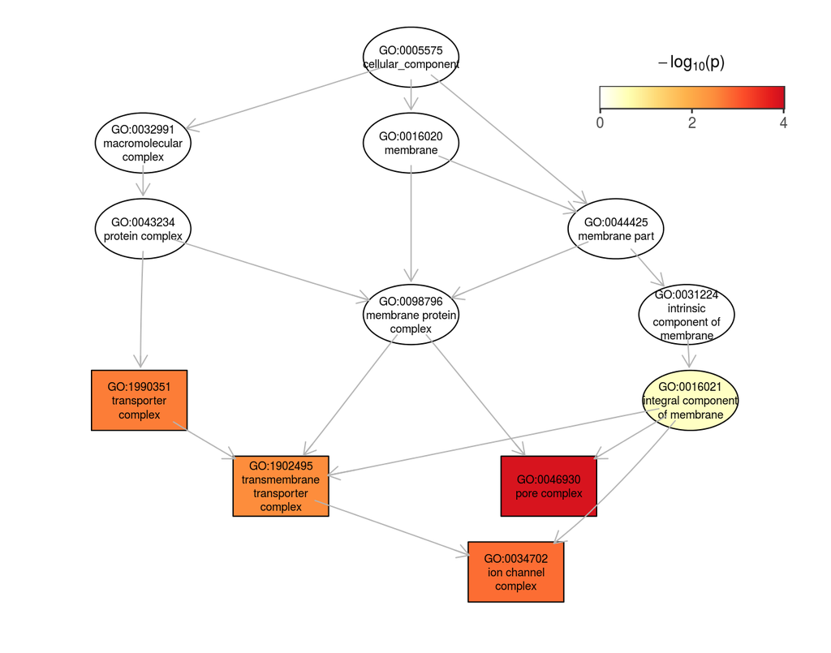

Significantly enriched GO terms are shown as rectangles, along with their relationship to parent terms in ellipses. Colours indicate -log$_{10}$ of the results from tests for enrichment. First and second level GO terms were not tested for enrichment.

```r
scaleEllipse <- 1.4
goPlot <- allCCPlot %>%
  reverseEdgeDirections() %>%
  layoutGraph(nodeAttrs = nodeAttrs, attrs = attrs, layoutType = "dot")
graphRI <- graphRenderInfo(goPlot)
graphRI$bbox <- matrix(c(-20, -40, 20, 20), byrow = TRUE, ncol=2) + graphRI$bbox
graphRenderInfo(goPlot) <- graphRI
nodeRI <- nodeRenderInfo(goPlot)
nodeRI$lWidth <- nodeRI$lWidth*scaleEllipse
nodeRI$rWidth <- nodeRI$rWidth*scaleEllipse
nodeRI$height <- nodeRI$height*scaleEllipse
nodeRenderInfo(goPlot) <- nodeRI
renderGraph(goPlot)
vp1 <- viewport(0.83, 0.86, 0.25, 0.14)
print(lg, vp = vp1)
```

## Molecular Function

```r
pcMF <- goInGenes$MF %>%
  mclapply(pcFun, ontology = "MF", minSig = minSigG, mc.cores = 20) %>%
  bind_rows() %>%
  filter(!is.na(p)) %>%
  mutate(adjP = p.adjust(p, "holm"),
         FDR = p.adjust(p, "BH"))
```

### First Plot of MF GO terms

```r
resFDR <- 0.1
sigMFGO <- pcMF %>%
  filter(FDR < resFDR,
         SigInChild > Expected) %>%
  extract2("Term")
```

The same series of preparatory steps was then undertaken as for the BP ontology., again using the same legend.

Next a `GraphNEL` object was prepared by merging individual graphs for each term, using the function `oneGOGraph`. The root GO term `all` was removed from these plots as it was redundant.

```r
allMFPlot <- oneGOGraph(sigMFGO[1], GOMFANCESTOR)
for (i in 2:length(sigMFGO)){
  allMFPlot %<>% join(oneGOGraph(sigMFGO[i], GOMFANCESTOR))
}
allMFPlot %<>% removeNode("all", .)
```

As this plot will contain edges connecting all nodes, edges not directly connecting parents and children need to be removed.

```r
nodeNames<- allMFPlot %>%
  nodeData() %>%
  names()
validEdges <- nodeNames %>%
  lapply(function(x){
    parents <- allParents$MF[[x]]
    paste(rep(x, length(parents)), parents, sep="|")
  }) %>%
  unlist()
rmEdges <- allMFPlot %>%
  edgeData() %>%
  names %>%
  setdiff(validEdges) %>%
  strsplit(split = "\\|") %>%
  as.data.frame() %>%
  t %>%
  set_rownames(c())
allMFPlot %<>% removeEdge(rmEdges[,1], rmEdges[,2], .)
```

Next the attributes for plotting each node need to be defined manually. This step unfortunately involved significant trial and error.

```r
termCols <- nodeNames %>%
  mclapply(pcFun, ontology = "MF", mc.cores = 20) %>%
  bind_rows() %>%
  mutate(p = -log10(p),
         p = replace(p, is.na(p), 0),
         colGrp = findInterval(p, pSeq)) %>%
  extract2("colGrp") %>%
  set_names(nodeNames)
termCols[!names(termCols) %in% pcMF$Term] <- NA
```

```r
nodeAttrs <- makeNodeAttrs(allMFPlot, shape = "ellipse", fillcolor=rgb(1, 1, 1))
nodeNames <- names(nodeAttrs$fillcolor)
nodeAttrs$fillcolor <- termCols[nodeNames] %>% set_names(nodeNames)
nodeAttrs$fillcolor[is.na(nodeAttrs$fillcolor)] <- 1
nodeAttrs$fillcolor <- plotCols[nodeAttrs$fillcolor] %>% set_names(nodeNames)
nodeAttrs$label <- paste(nodeNames,
                         str_wrap(str_trunc(Term(nodeNames), width = 41), 18),
                         sep = "\n") %>%
  set_names(nodeNames)
nodeAttrs$shape[sigMFGO] <- "rectangle"
attrs <- list(node = list(fontsize = 16,
                          fixedSize =  FALSE),
              edge = list(color = "grey70"))
```

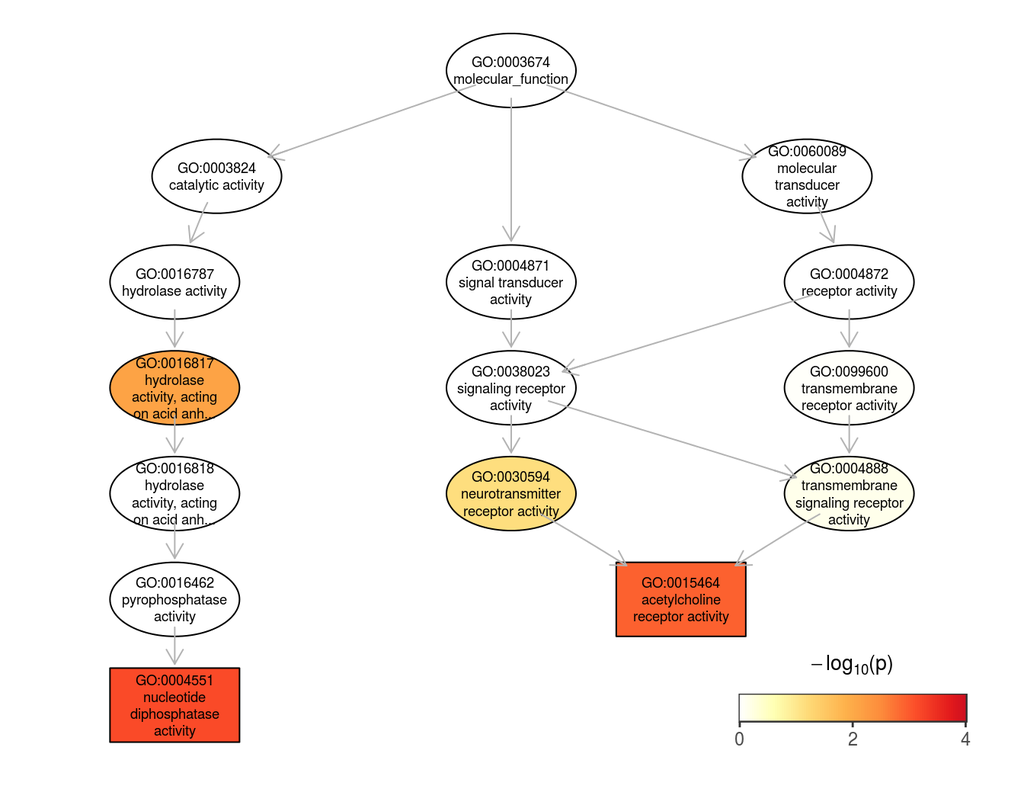

Significantly enriched GO terms are shown as rectangles, along with their relationship to parent terms in ellipses. Colours indicate -log$_{10}$ of the results from tests for enrichment. First and second level GO terms were not tested for enrichment.

```r
scaleEllipse <- 1.4
goPlot <- allMFPlot %>%
  reverseEdgeDirections() %>%
  layoutGraph(nodeAttrs = nodeAttrs, attrs = attrs, layoutType = "dot")
graphRI <- graphRenderInfo(goPlot)
graphRI$bbox <- matrix(c(-20, -40, 20, 20), byrow = TRUE, ncol=2) + graphRI$bbox
graphRenderInfo(goPlot) <- graphRI
nodeRI <- nodeRenderInfo(goPlot)
nodeRI$lWidth <- nodeRI$lWidth*scaleEllipse*1.1
nodeRI$rWidth <- nodeRI$rWidth*scaleEllipse*1.1
nodeRI$height <- nodeRI$height*scaleEllipse
nodeRenderInfo(goPlot) <- nodeRI
renderGraph(goPlot)
vp1 <- viewport(0.83, 0.13, 0.25, 0.14)
print(lg, vp = vp1)
```

### GO Terms to Genes

```r
pcMF %>%
  filter(Term %in% sigMFGO) %>%
  mutate(Description = Term(Term)) %>%
  dplyr::select(Term, Description) %>%
  split(f = .$Term) %>%
  lapply(function(df){
    out <- names(fullGene$MF) %>%
      extract(vapply(fullGene$MF, function(x){df$Term %in% x}, logical(1))) %>%
      intersect(sigIDs) %>%
      data_frame() %>%
      set_names("ensembl_gene_id") %>%
      left_join(dplyr::select(snpScores, ensembl_gene_id, gene_name)) %>%
      mutate(`Term` = df[["Term"]],
             Description = df[["Description"]])
  }) %>%
  bind_rows() %>%
  readr::write_csv("../results/topMFGenes.csv")
```

# Appendix

```r
save.image("goEnrichment20170214.RData")
```